# Cost-Effectivness Analysis

Nate Talampas

# Background

Cost-effectiveness analysis (CEA) constitutes a method of economic assessment that contrasts the expenses, efficiency, and outcomes of distinct strategies to achieve desired benefits. The primary objective of cost-effectiveness analysis is to pinpoint the strategy that delivers the maximum benefit while maintaining an acceptable level of efficiency. The measure of effectiveness is commonly expressed in quality-adjusted life-years (QALYs), although alternative metrics such as life-years, infections or cases averted, may be employed based on the decision maker’s objectives. Costs encompass the implementation expenses of the strategy and any pertinent downstream costs.

In the initial stage of evaluating cost-effectiveness for a set of mutually exclusive strategies, the first step involves arranging the strategies in ascending order based on their associated costs. The expectation is that as costs rise, effectiveness should also increase. If a strategy exhibits both lower effectiveness and higher costs compared to another, it is considered “strongly dominated.” A rational decision-maker would refrain from implementing a dominated strategy, as opting for a different strategy could achieve greater effectiveness at a lower cost (given the mutually exclusive nature of the strategies). Consequently, dominated strategies are excluded from further consideration in the analysis.

After ordering strategies by increasing costs, the next step is to calculate the incremental cost and incremental effectiveness when moving from one strategy to the next. This involves determining the Incremental Cost-Effectiveness Ratio (ICER) for each strategy, which is found by dividing its incremental costs by its incremental effectiveness. Essentially, the ICER represents the cost per unit benefit of upgrading to a specific strategy from the next least costly and least effective one.

At this stage, we identify “weakly dominated” strategies. These are strategies that can be outperformed by a combination of two different strategies, showcasing either lower costs or higher effectiveness. Detecting weak dominance, also known as “extended dominance,” involves checking if ICERs increase consistently with increasingly costly and effective strategies. Any deviation or “kink” in this trend indicates weak/extended dominance.

Once weakly dominated strategies are eliminated, and the incremental values are recalculated, the remaining set of strategies forms the efficient frontier. The associated ICERs can then be assessed to inform decision-making.

# Ex 1: CEA using average cost and effectiveness of HIV Screening strategies in the US

In this scenario, a model was employed to analyze the costs, benefits, and cost-effectiveness associated with various HIV screening frequencies across diverse populations characterized by distinct HIV prevalence and incidence rates. To showcase the Cost-Effectiveness Analysis (CEA) functionality, our emphasis will be on evaluating HIV screening frequencies within a high-risk population with a prevalence of 1.0% and an annual incidence of 0.12%. Notably, the assessment focuses solely on patient-level benefits, deliberately excluding any considerations related to the reduction in secondary HIV transmission.

### Data

Five strategies are considered: No specific screening recommendation (status quo), one-time HIV test, HIV testing every 5 years, HIV testing every 3 years, and HIV test annually.Costs and QALYs are defined in: https://www.acpjournals.org/doi/10.7326/0003-4819-145-11-200612050-00004#ta4-4

```r
library(dampack)
# defining strategy names
hiv_strat_names = c("status quo", "one time", "5yr", "3yr", "annual")
# average costs per person
hiv_costs = c(26000, 27000, 28020, 28440, 29440)
# QALYs
hiv_qalys <- c(277.25, 277.57, 277.78, 277.83, 277.76) / 12
```

### Calculate ICERs (incremental cost-effectivness ratio)

```r
# conducting cost-effectiveness comparison fo the five HIV testing strategies
icer_hiv <- calculate_icers(cost=hiv_costs,
                            effect=hiv_qalys,
                            strategies=hiv_strat_names)
icer_hiv %>%
  kable() %>%
  kable_styling()
```

| Strategy | Cost | Effect | Inc_Cost | Inc_Effect | ICER | Status |
| --- | --- | --- | --- | --- | --- | --- |
| status quo | 26000 | 23.10417 | NA | NA | NA | ND |
| one time | 27000 | 23.13083 | 1000 | 0.0266667 | 37500.00 | ND |
| 5yr | 28020 | 23.14833 | 1020 | 0.0175000 | 58285.71 | ND |
| 3yr | 28440 | 23.15250 | 420 | 0.0041667 | 100800.00 | ND |
| annual | 29440 | 23.14667 | NA | NA | NA | D |

The default view is ordered by dominance status (ND = non-dominated, ED = extended/weak dominance, or D = strong dominance), and then ascending by cost.

### Plotting CEA results

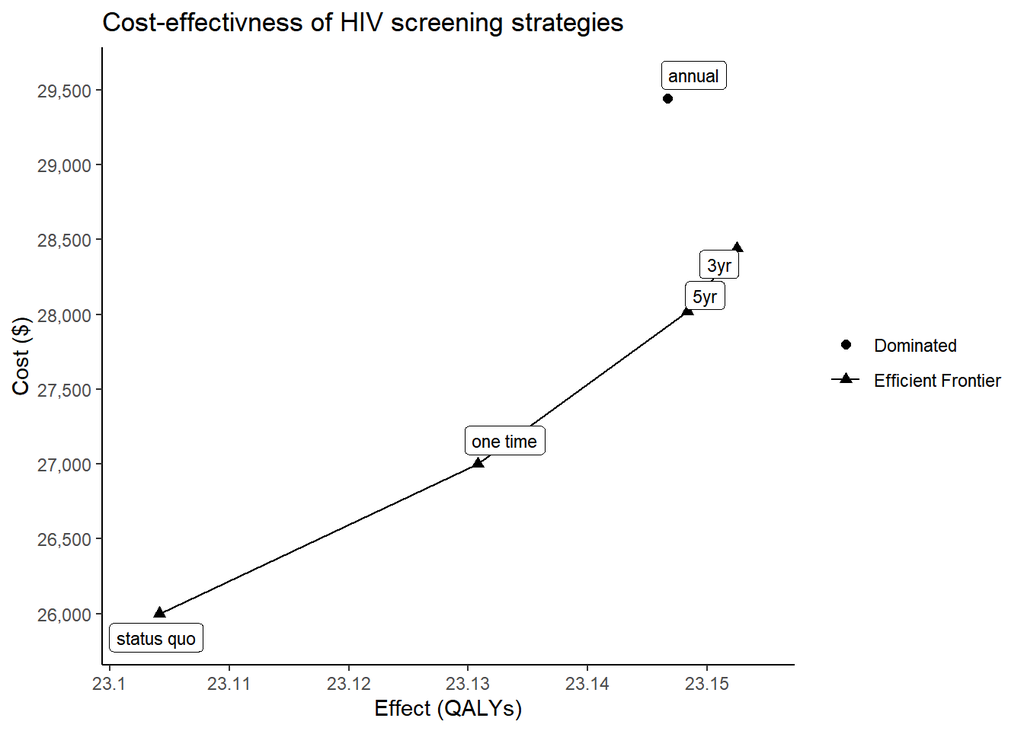

```r
plot(icer_hiv
     ,label="all") +
  theme_classic() +
  ggtitle("Cost-effectivness of HIV screening strategies")
```

# Ex 2: CEA using a probabilistic sensitivity analysis of treatment strategies

### Data

The Clostridioides difficile dataset is provided within `dampack` and can be accessed using the `data()` function.

```r
library(dampack)
data("psa_cdiff")
```

We need to calculate the average cost and average effectiveness for each strategy across the PSA samples.

```r
cdiff.df = summary(psa_cdiff)
cdiff.df
```

```
##    Strategy meanCost meanEffect
## 1        s3 57336.01   12.93996
## 2       s27 57541.25   13.01406
## 3       s33 57642.26   13.03891
## 4       s31 57934.07   13.09663
## 5       s43 58072.11   13.11286
## 6       s44 58665.78   13.12833
## 7       s13 58018.63   13.06504
## 8       s39 57814.65   13.04628
## 9       s20 58634.20   13.11006
## 10      s37 58081.79   13.10297
## 11       s4 57887.48   12.99707
```

The specifications of each strategy can be found in https://doi.org/10.1093/cid/ciz318.

### Calculate ICERs

```r
# conducting CEA comparisons
icer_cdiff = calculate_icers(cost = cdiff.df$meanCost,
                             effect = cdiff.df$meanEffect,
                             strategies = cdiff.df$Strategy)

icer_cdiff %>%
  kable() %>%
  kable_styling()
```

| Strategy | Cost | Effect | Inc_Cost | Inc_Effect | ICER | Status |
| --- | --- | --- | --- | --- | --- | --- |
| s3 | 57336.01 | 12.93996 | NA | NA | NA | ND |
| s27 | 57541.25 | 13.01406 | 205.2466 | 0.0741001 | 2769.855 | ND |
| s33 | 57642.26 | 13.03891 | 101.0061 | 0.0248476 | 4065.031 | ND |
| s31 | 57934.07 | 13.09663 | 291.8156 | 0.0577142 | 5056.222 | ND |
| s43 | 58072.11 | 13.11286 | 138.0394 | 0.0162319 | 8504.216 | ND |
| s44 | 58665.78 | 13.12833 | 593.6686 | 0.0154752 | 38362.652 | ND |
| s39 | 57814.65 | 13.04628 | NA | NA | NA | ED |
| s4 | 57887.48 | 12.99707 | NA | NA | NA | D |
| s13 | 58018.63 | 13.06504 | NA | NA | NA | D |
| s37 | 58081.79 | 13.10297 | NA | NA | NA | D |
| s20 | 58634.20 | 13.11006 | NA | NA | NA | D |

In this example, 5 of the 11 strategies are dominated. Four are strongly dominated and one is weakly dominated. We will remove dominated strategies from the CEA results table using `fiter()`.

```r
icer_cdiff %>%
  filter(Status == "ND") %>%
  kable() %>%
  kable_styling()
```

| Strategy | Cost | Effect | Inc_Cost | Inc_Effect | ICER | Status |
| --- | --- | --- | --- | --- | --- | --- |
| s3 | 57336.01 | 12.93996 | NA | NA | NA | ND |
| s27 | 57541.25 | 13.01406 | 205.2466 | 0.0741001 | 2769.855 | ND |
| s33 | 57642.26 | 13.03891 | 101.0061 | 0.0248476 | 4065.031 | ND |
| s31 | 57934.07 | 13.09663 | 291.8156 | 0.0577142 | 5056.222 | ND |
| s43 | 58072.11 | 13.11286 | 138.0394 | 0.0162319 | 8504.216 | ND |
| s44 | 58665.78 | 13.12833 | 593.6686 | 0.0154752 | 38362.652 | ND |

### Plot CEA results

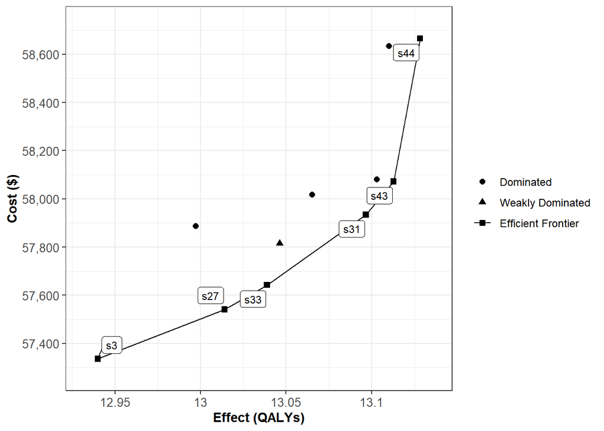

```r
plot(icer_cdiff)
```

```r
#plot(icer_cdiff, label = "all")
```

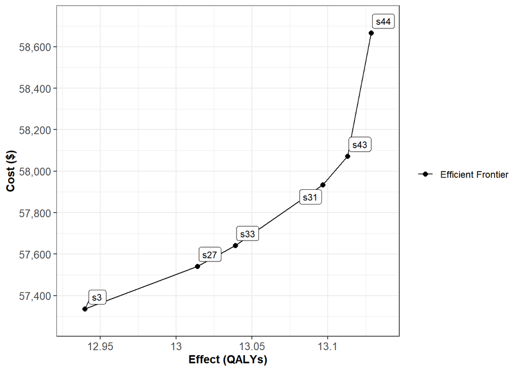

```r
# removing dominated strategies from plot
plot(icer_cdiff, plot_frontier_only = T)
```

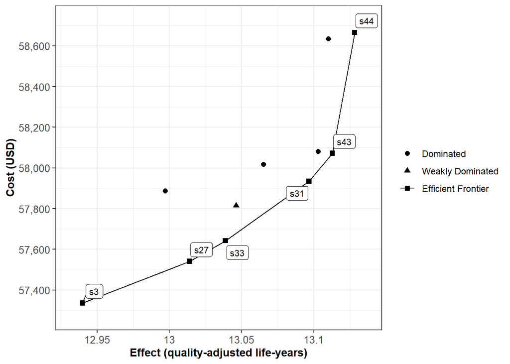

```r
plot(icer_cdiff, currency = "USD", effect_units = "quality-adjusted life-years")
```